# Part 2: Productivity vs Stability

Created January, 2023

PME

10 March, 2024, 07:23

# Overview

Steps:

1. Load
2. Assess productivity of rotations
3. Calculate rotation yield within rotation-block-year
4. ANOVA
5. Environmental index analysis of rotations
6. Calculate environmental index = weighted average yield across rotations within block-year.
7. Yield vs environmental index
8. Assess expected yield (means)
9. Assess buffering (environmental index)
10. Rank rep-years by means of all crops
11. Run environmental index analysis
12. Assess productivity-stability Relationships

## Load

```r
libs = c(
  'here',
  'magrittr',
  'tidyr',
  'lme4',
  'car',
  'ggplot2',
  'gridExtra',
  'emmeans',
  'multcomp',
  # 'wesanderson',
  'ggpmisc',
  'ggExtra',
  'ggtext'
)

for (i in libs) {
  if (!require(i, character.only=TRUE)) {
    renv::install(i)
    library(i, character.only=TRUE)
  }
}
```

[output not shown]

[output not shown]

[output not shown]

```r
se = function(x) sd(x)/sqrt(length(x))

# slightly tuned Paired2 from color brewer
rot_colors = c(
  CS     = '#444444', # dark gray
  CCaWwS = '#B2DF8A', # light green
  CSSwS  = '#33A02C', # green
  COWwS  = '#FB9A99', # light red
  CCSSw  = '#E31A1C', # red
  CPWwS  = '#a89ad0', # light purple
  CSSwP  = '#6951b6'  # purple
)

# rot_colors = wes_palette('Darjeeling1', 3)
rot_colors = c('#E8601C',
               '#4EB265',
               '#1965B0')
rot_colors %<>% {c(
  CS = '#444444',
  CCaWwS = .[2],
  CSSwS = .[2],
  COWwS = .[3],
  CCSSw = .[3],
  CPWwS = .[1],
  CSSwP = .[1]
)}
```

```r
in_dir = 'Data'
in_crop = 'crop performance.csv'
in_rot = 'rotation performance.csv'

out_dir = 'Results'

crop = here(in_dir, in_crop) %>%
  read.csv

rot = here(in_dir, in_rot) %>%
  read.csv
```

ensure factors are flagged as such

```r
facts =
  c('YEAR',
    'ROTATION',
    'REP',
    'CYCLE',
    'CYCLE_YEAR')
crop[, facts] %<>% lapply(as.factor)
rot[, facts] %<>% lapply(as.factor)

# rot_colors %<>% .[levels(crop$ROTATION)]
crop[, 'ROTATION'] %<>% factor(levels=names(rot_colors))
rot[, 'ROTATION'] %<>% factor(levels=names(rot_colors))

# Convert yield to Mg ha
crop$YIELD = crop$YIELD/1000
rot$YIELD = rot$YIELD/1000
```

# Rotation Performance

This is mean yield across crops within a rotation

## Model and diagnostics

```r
pred = 'ROTATION'
rand = '(1|CYCLE/CYCLE_YEAR) + (1|REP/CYCLE_YEAR)'
resp = 'YIELD'

mod = paste(resp, '~', pred, '+', rand) %>%
  formula %>%
  lmer(data=rot)
```

```
## boundary (singular) fit: see help('isSingular')
```

```r
Anova(mod, test.statistic='F')
```

|  | F | Df | Df.res | Pr(>F) |
| --- | --- | --- | --- | --- |
| ROTATION | 41.8889 | 6 | 414.0002 | 7.05349e-40 |

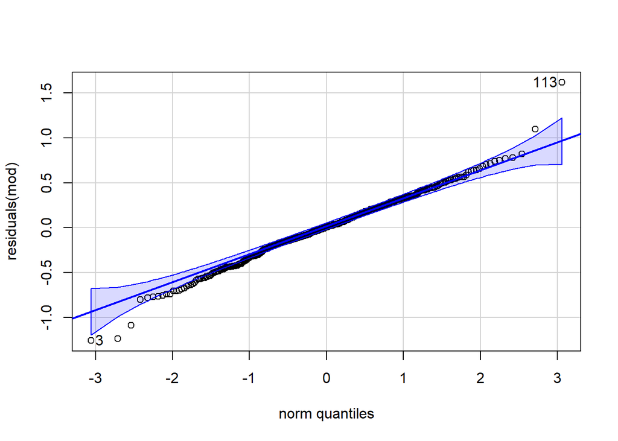

```
## [1] 113   3
```

```r
qqPlot(residuals(mod))
```

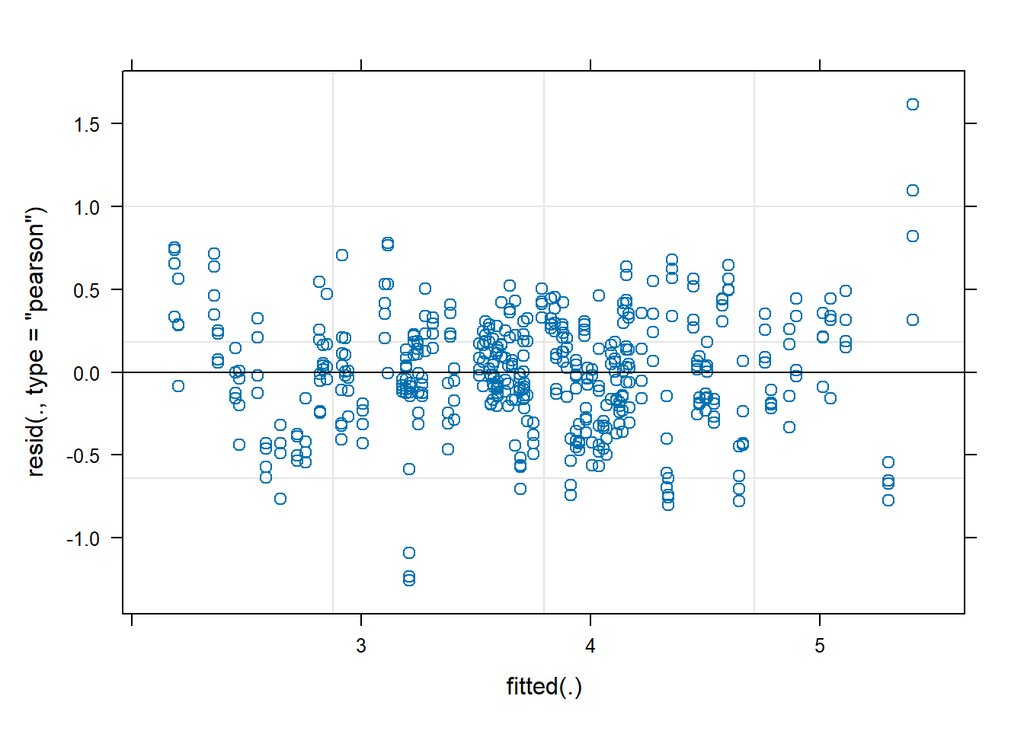

```r
plot(mod)
```

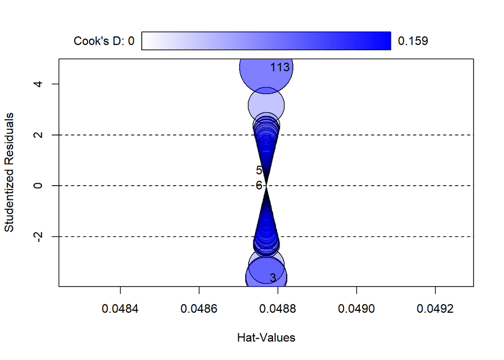

|  | StudRes | Hat | CookD |
| --- | --- | --- | --- |
| 3 | -3.62234861 | 0.04877025 | 9.610632e-02 |
| 5 | 0.59611212 | 0.04877025 | 2.602720e-03 |
| 6 | 0.01436348 | 0.04877025 | 1.511092e-06 |
| 113 | 4.65497141 | 0.04877025 | 1.587104e-01 |

```r
influencePlot(mod)
```

Looks good.

## Results

```r
mod_emm =
  emmeans(mod, pred) %>%
  cld(p.adjust='fdr', Letters=letters, reverse=TRUE) %T>%
  print
```

```
##  ROTATION emmean    SE   df lower.CL upper.CL .group
##  CS         4.10 0.177 3.35     3.57     4.64  a
##  COWwS      4.00 0.177 3.35     3.46     4.53  ab
##  CCSSw      3.81 0.177 3.35     3.28     4.34   bc
##  CSSwP      3.75 0.177 3.35     3.21     4.28    c
##  CPWwS      3.71 0.177 3.35     3.18     4.24    c
##  CSSwS      3.36 0.177 3.35     2.83     3.89     d
##  CCaWwS     3.35 0.177 3.35     2.82     3.88     d
##
## Degrees-of-freedom method: kenward-roger
## Confidence level used: 0.95
## P value adjustment: tukey method for comparing a family of 7 estimates
## significance level used: alpha = 0.05
## NOTE: If two or more means share the same grouping symbol,
##       then we cannot show them to be different.
##       But we also did not show them to be the same.
```

```r
emmeans(mod, pred) %>%
  pairs(adjust='fdr')
```

```
##  contrast       estimate    SE  df t.ratio p.value
##  CS - CCaWwS      0.7572 0.063 414  12.019  <.0001
##  CS - CSSwS       0.7407 0.063 414  11.758  <.0001
##  CS - COWwS       0.1083 0.063 414   1.720  0.1065
##  CS - CCSSw       0.2934 0.063 414   4.658  <.0001
##  CS - CPWwS       0.3938 0.063 414   6.251  <.0001
##  CS - CSSwP       0.3586 0.063 414   5.693  <.0001
##  CCaWwS - CSSwS  -0.0164 0.063 414  -0.261  0.7943
##  CCaWwS - COWwS  -0.6488 0.063 414 -10.299  <.0001
##  CCaWwS - CCSSw  -0.4637 0.063 414  -7.361  <.0001
##  CCaWwS - CPWwS  -0.3634 0.063 414  -5.768  <.0001
##  CCaWwS - CSSwP  -0.3985 0.063 414  -6.326  <.0001
##  CSSwS - COWwS   -0.6324 0.063 414 -10.039  <.0001
##  CSSwS - CCSSw   -0.4473 0.063 414  -7.101  <.0001
##  CSSwS - CPWwS   -0.3469 0.063 414  -5.507  <.0001
##  CSSwS - CSSwP   -0.3821 0.063 414  -6.065  <.0001
##  COWwS - CCSSw    0.1851 0.063 414   2.938  0.0046
##  COWwS - CPWwS    0.2854 0.063 414   4.531  <.0001
##  COWwS - CSSwP    0.2503 0.063 414   3.973  0.0001
##  CCSSw - CPWwS    0.1004 0.063 414   1.593  0.1305
##  CCSSw - CSSwP    0.0652 0.063 414   1.035  0.3328
##  CPWwS - CSSwP   -0.0352 0.063 414  -0.558  0.6060
##
## Degrees-of-freedom method: kenward-roger
## P value adjustment: fdr method for 21 tests
```

```r
group_letters = function(x) {
  grp = x$.group  %>%
    trimws %>%
    strsplit(split="")
  maxgrp = unlist(x$.group) %>%
    as.numeric %>%
    max
  grp %<>% sapply(function(y) {
    y %<>% as.numeric
    y = maxgrp - y + 1
    y %<>% sort(decreasing=FALSE) %>%
      letters[.] %>%
      paste(collapse='')
    y
  })

  out = data.frame(
    x[1],
    GROUP=grp
  )
  return(out)
}

mean_se = function(...) {
  out = aggregate(..., function(x) {
    se = sd(x)/sqrt(length(x))
    mn = mean(x)
    c(
      mean=mn,
      se=se,
      se_high=mn + se,
      se_low=mn - se)
  }) |>
    lapply(unlist) |>
    data.frame()

  nn = length(names(out))
  nn = seq(nn-3, nn, by=1)
  names(out)[nn] = c('mean', 'se', 'err_high', 'err_low')
  return(out)
}
```

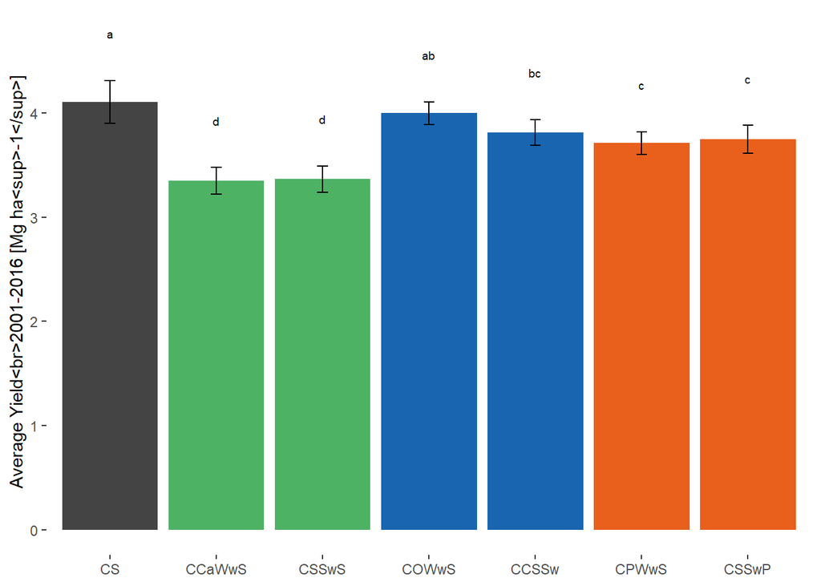

```r
productivity = mean_se(YIELD ~ ROTATION, data=crop) |>
  merge(mod_emm,
        by='ROTATION')

productivity_plt =
  ggplot(productivity,
         aes(x=ROTATION,
             y=mean,
             fill=ROTATION)) +
  scale_fill_manual(values=rot_colors) +
  # scale_fill_brewer(palette='Paired') +
  geom_col() +
  geom_errorbar(aes(ymin=err_low,
                    ymax=err_high),
                width=0.1) +
  geom_text(aes(y=err_high+0.450,
                label=trimws(.group)),
            size=2.5) +
  labs(x=NULL,
       y='Average Yield<br>2001-2016 [Mg ha<sup>-1</sup>]',
       fill=NULL) +
  guides(fill='none') +
  theme(panel.background=element_blank(),
        axis.title=element_markdown())
productivity_plt
```

## Discussion COWwS and CS were highest yielding. CCaWwS and CSSwS were lowest yielding.

# Stability

Via environmental index (mean yield within years, scaled across years)

## Calculate indices

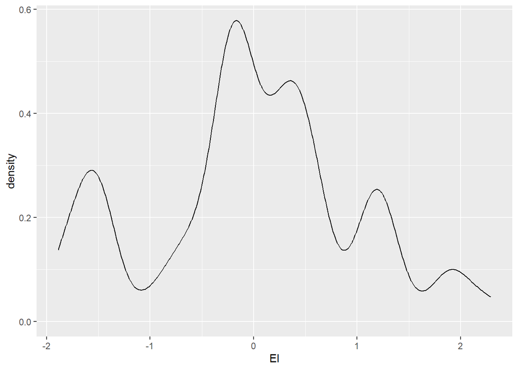

```r
ei = aggregate(YIELD ~ ROTATION + REP + YEAR, data=crop, mean) %>%
  aggregate(YIELD ~ REP + YEAR, data=., mean) # average annual block yields including imputed values
names(ei) %<>% gsub('YIELD', 'EI', .)
ei$EI %<>% scale

ei %<>% merge(rot, by=c('REP', 'YEAR'))
ggplot(ei,
       aes(x=EI)) +
  geom_density()
```

## Model and diagnostics

```r
pred = 'EI*ROTATION'
rand = 'REP'
resp = 'YIELD'

mod = paste(resp, '~', pred, '+', rand) %>%
  formula %>%
  lm(data=ei)
mod_av = Anova(mod, test.statistic='F') %T>%
  print
```

```
## Anova Table (Type II tests)
##
## Response: YIELD
##              Sum Sq  Df  F value Pr(>F)
## EI          191.141   1 1951.429 <2e-16 ***
## ROTATION     31.917   6   54.309 <2e-16 ***
## REP           0.000   3    0.000      1
## EI:ROTATION  10.053   6   17.106 <2e-16 ***
## Residuals    42.216 431
## ---
## Signif. codes:  0 '***' 0.001 '**' 0.01 '*' 0.05 '.' 0.1 ' ' 1
```

A significant interaction and a significant main effect of rotation.

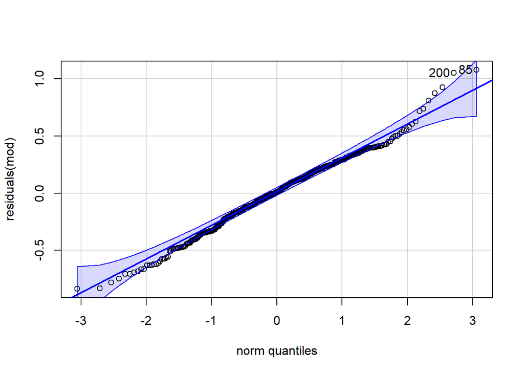

```
## [1]  85 200
```

```r
qqPlot(residuals(mod))
```

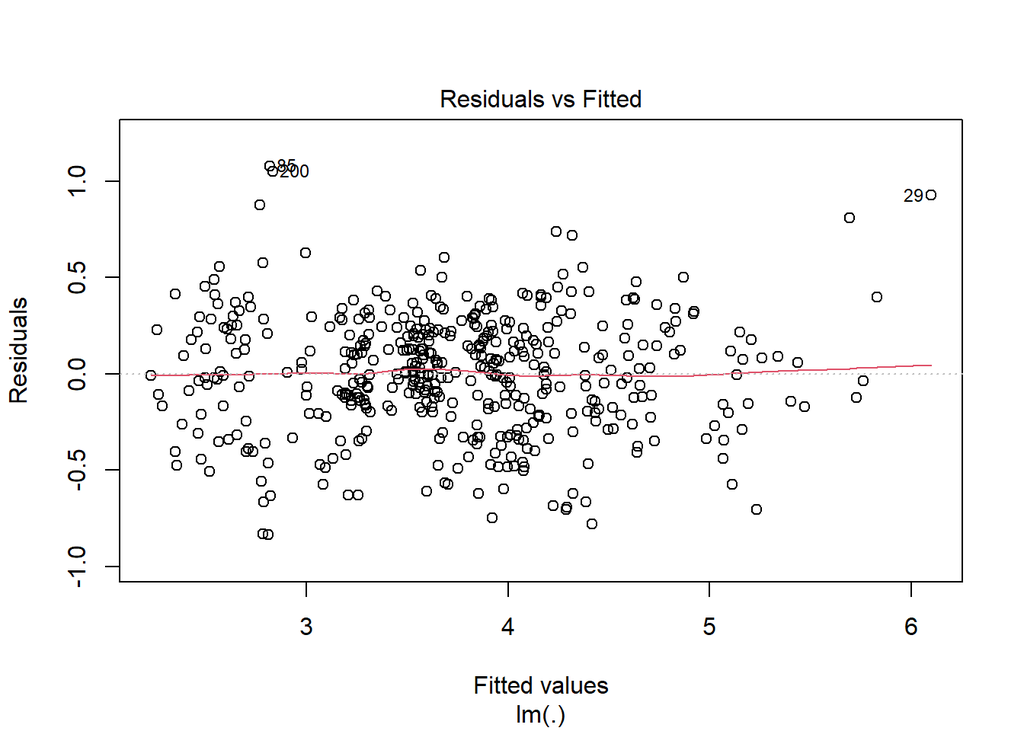

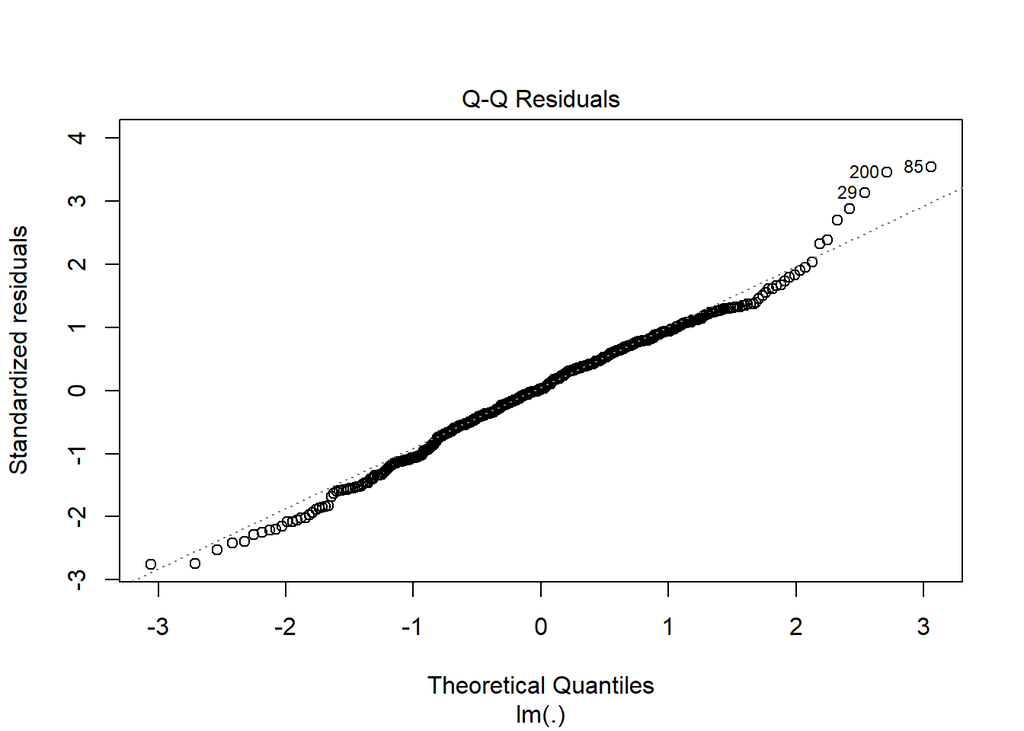

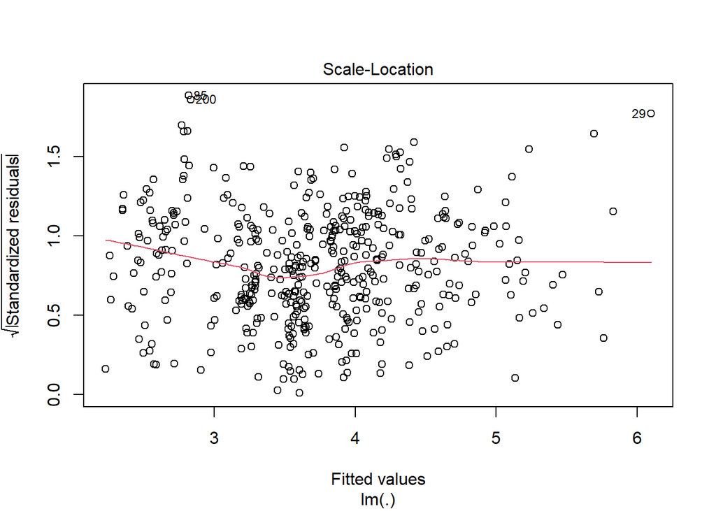

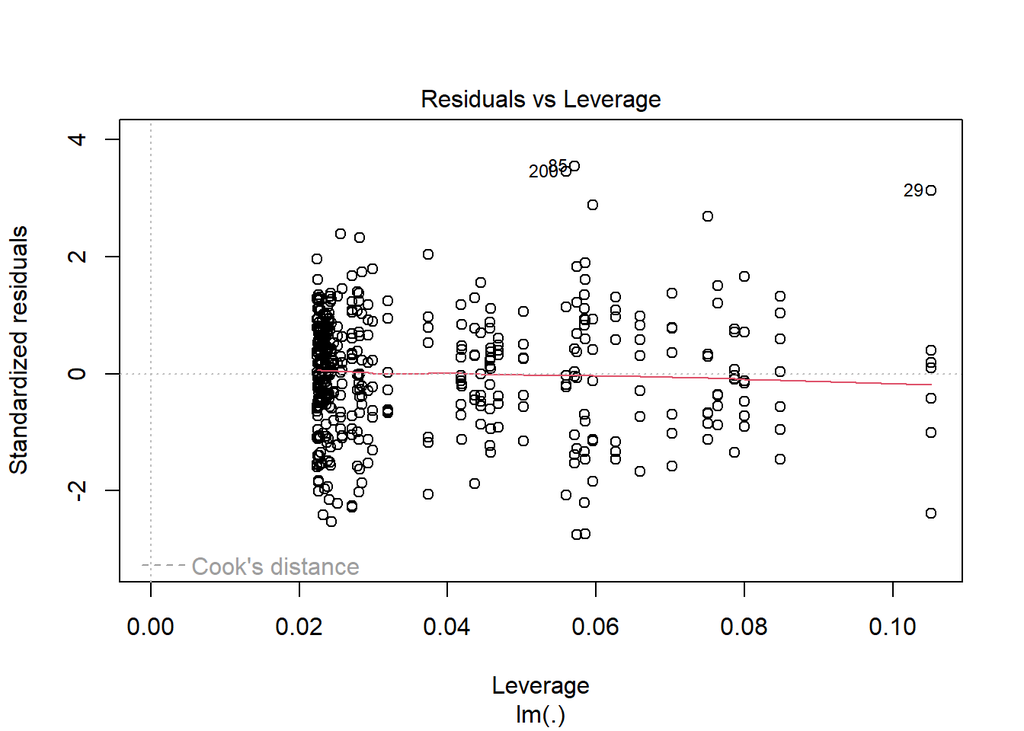

```r
plot(mod)
```

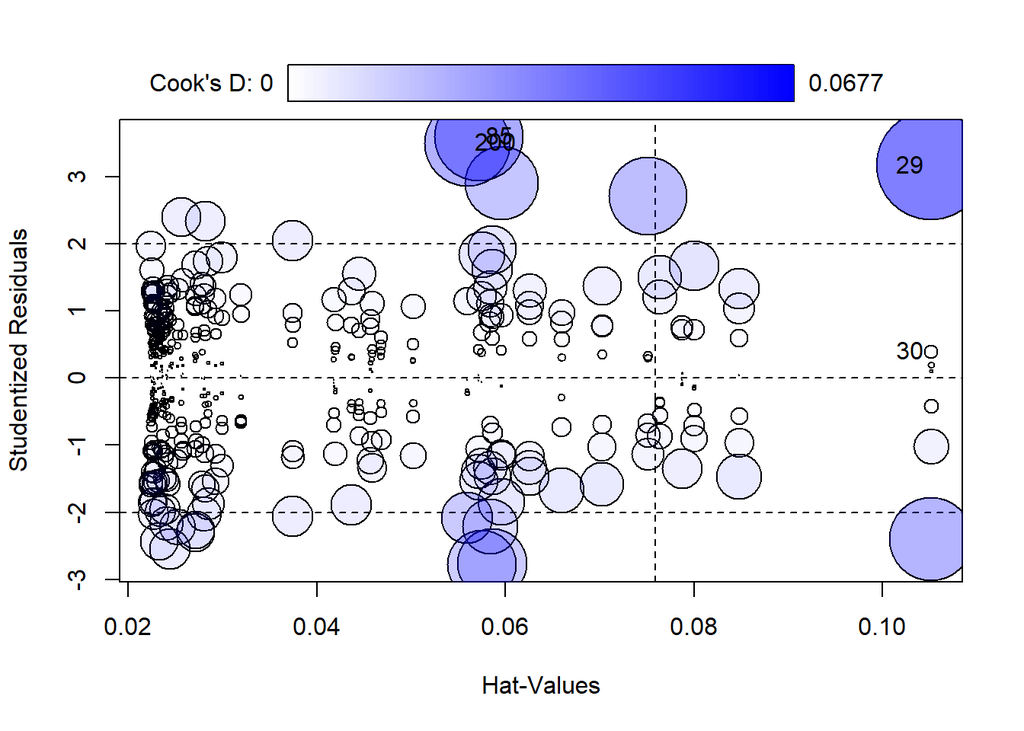

|  | StudRes | Hat | CookD |
| --- | --- | --- | --- |
| 29 | 3.1629338 | 0.10516195 | 0.067743240 |
| 30 | 0.3934901 | 0.10516195 | 0.001072471 |
| 85 | 3.5949617 | 0.05712957 | 0.044822581 |
| 200 | 3.5013087 | 0.05597663 | 0.041671230 |

```r
influencePlot(mod)
```

Looks good.

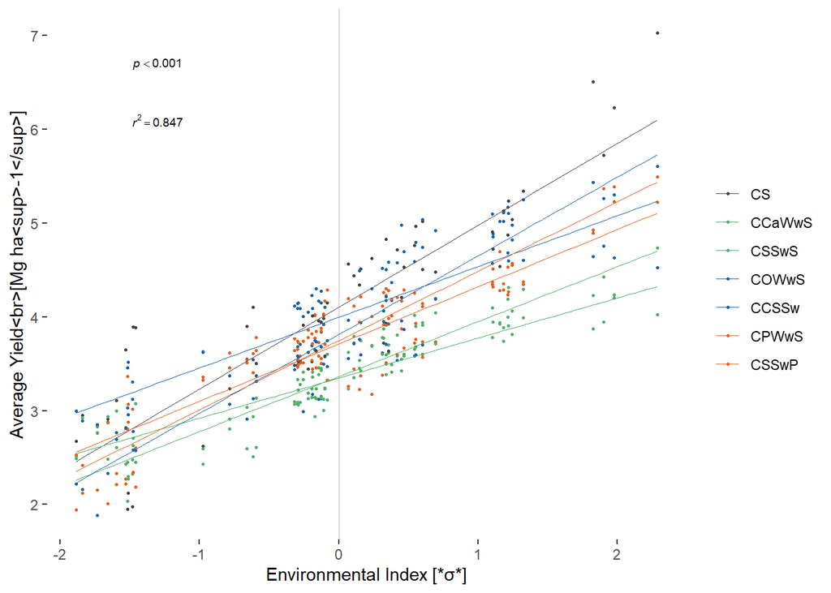

```r
ei_plt =
  ggplot(ei,
         aes(x=EI,
             y=.data[[resp]],
             color=ROTATION)) +
  scale_color_manual(values=rot_colors) +
  geom_vline(aes(xintercept=0),
             color='gray',
             size=0.2) +
  geom_point(size=0.5) +
  geom_smooth(method='lm',
              formula='y~x',
              se=FALSE,
              size=0.3) +
  labs(x='Environmental Index [*σ*]',
       y='Average Yield<br>[Mg ha<sup>-1</sup>]',
       color=NULL) +
  annotate(geom='text',
           x=-1.3,
           y=6.700,
           label=paste("italic(p)<0.001"),
           parse=TRUE,
           size=2.5) +
  annotate(geom='text',
           x=-1.3,
           y=6.100,
           label=paste("italic(r)^2==", round(summary(mod)$r.squared, 3)),
           parse=TRUE,
           size=2.5) +
  theme(panel.background=element_blank(),
        legend.key=element_blank(),
        axis.title=element_markdown())
ei_plt
```

```r
mod_emm =
  emtrends(mod, 'ROTATION', 'EI') %>%
  cld(adjust='fdr', Letters=letters, reverse=TRUE) %T>%
  print
```

```
##  ROTATION EI.trend     SE  df lower.CL upper.CL .group
##  CS          0.871 0.0394 431    0.765    0.978  a
##  CCSSw       0.838 0.0394 431    0.731    0.945  ab
##  CSSwP       0.739 0.0394 431    0.632    0.845   b
##  CPWwS       0.610 0.0394 431    0.503    0.716    c
##  CSSwS       0.585 0.0394 431    0.478    0.692    c
##  COWwS       0.540 0.0394 431    0.434    0.647    cd
##  CCaWwS      0.426 0.0394 431    0.320    0.533     d
##
## Results are averaged over the levels of: REP
## Confidence level used: 0.95
## Conf-level adjustment: bonferroni method for 7 estimates
## P value adjustment: fdr method for 21 tests
## significance level used: alpha = 0.05
## NOTE: If two or more means share the same grouping symbol,
##       then we cannot show them to be different.
##       But we also did not show them to be the same.
```

```r
pwpm(emtrends(mod, 'ROTATION', 'EI'), adjust='fdr')
```

```
##             CS  CCaWwS   CSSwS   COWwS   CCSSw   CPWwS   CSSwP
## CS     [0.871]  <.0001  <.0001  <.0001  0.5779  <.0001  0.0267
## CCaWwS  0.4450 [0.426]  0.0081  0.0546  <.0001  0.0021  <.0001
## CSSwS   0.2863 -0.1586 [0.585]  0.4681  <.0001  0.6577  0.0099
## COWwS   0.3310 -0.1140  0.0447 [0.540]  <.0001  0.2497  0.0009
## CCSSw   0.0333 -0.4116 -0.2530 -0.2977 [0.838]  0.0001  0.0932
## CPWwS   0.2616 -0.1834 -0.0247 -0.0694  0.2283 [0.610]  0.0298
## CSSwP   0.1327 -0.3123 -0.1536 -0.1983  0.0994 -0.1289 [0.739]
##
## Row and column labels: ROTATION
## Upper triangle: P values   adjust = "fdr"
## Diagonal: [Estimates] (EI.trend)
## Lower triangle: Comparisons (estimate)   earlier vs. later
```

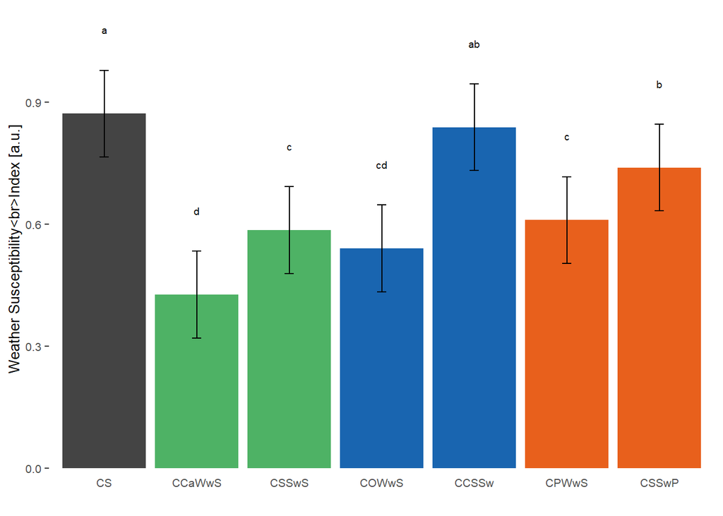

```r
stability_plt =
  ggplot(mod_emm,
         aes(x=ROTATION,
             y=EI.trend,
             fill=ROTATION)) +
  scale_fill_manual(values=rot_colors) +
  geom_col() +
  geom_errorbar(aes(ymin=lower.CL,
                    ymax=upper.CL),
                width=0.1) +
  geom_text(aes(label=trimws(.group),
                y=upper.CL+0.1),
            size=2.5) +
  labs(x=NULL,
       y='Weather Susceptibility<br>Index [a.u.]') +
  guides(fill='none') +
  theme(panel.background=element_blank(),
        axis.ticks.x=element_blank(),
        axis.text.x=element_text(vjust=10),
        text=element_text(size=10),
        axis.title=element_markdown())
stability_plt
```

# Productivity vs Stability

```r
pred = "EI:REP:ROTATION"
rep_ei = paste(resp, pred, sep='~') %>%
  formula %>%
  lm(data=ei) %>%
  coef %>%
  .[-c(1)] %>%
  data.frame(do.call(rbind, strsplit(names(.), ':')),
             value=.) %>%
  set_rownames(NULL) %>%
  set_colnames(c('EI', 'REP', 'ROTATION', 'SLOPE'))
rep_ei$EI = NULL
rep_ei$REP %<>% gsub('REP', '', .) %>%
  factor(levels=levels(ei$REP))
rep_ei$ROTATION %<>% gsub('ROTATION', '', .) %>%
  factor(levels=levels(ei$ROTATION))

rep_prod = paste(resp, 'REP:ROTATION', sep='~') %>%
  formula %>%
  aggregate(ei, mean)

cv_prod = paste(resp, 'REP:ROTATION', sep='~') %>%
  formula %>%
  aggregate(ei, function(x) 100*sd(x)/mean(x)) %>%
  set_colnames(c('REP', 'ROTATION', 'CV'))

prod_ei = merge(rep_prod, rep_ei, by=c('REP', 'ROTATION')) %>%
  merge(cv_prod, by=c('REP', 'ROTATION'))

ps_mod = lm(SLOPE ~ YIELD, data=prod_ei)

ps_test = Anova(ps_mod) %T>%
  print
```

```
## Anova Table (Type II tests)
##
## Response: SLOPE
##            Sum Sq Df F value    Pr(>F)
## YIELD     0.26861  1  16.835 0.0003572 ***
## Residuals 0.41484 26
## ---
## Signif. codes:  0 '***' 0.001 '**' 0.01 '*' 0.05 '.' 0.1 ' ' 1
```

```r
quadrants = data.frame(
  x = c(3390, 4150, 3800, 3780)/1000,
  y = c(660, 660, 950, 380)/1000,
  label = c('Less\nProductive',
            'More\nProductive',
            'Variable',
            'Stable')
)

convex_hull = split(prod_ei, prod_ei$ROTATION) %>%
  lapply(function(x) {
    tt = x[, c('ROTATION', 'YIELD', 'SLOPE')] %>%
      .[chull(.[, c(2, 3)]), ]
  }) %>%
  do.call(rbind, .)

centers = sapply(c('YIELD', 'SLOPE'),
                 function(x) tapply(prod_ei[, x], prod_ei$ROTATION, mean)) %>%
  as.data.frame
centers$ROTATION = rownames(centers)
```

## Outliers

The estimate here is the percentage discrepancy of observed weather dependency relative to expected weather dependency given a sample unit’s productivity.

```r
prod_ei$resid = residuals(ps_mod)
prod_ei$fit = fitted(ps_mod)

ei_ttest = with(prod_ei, tapply(resid/fit, ROTATION, t.test))
ei_ttest %<>% lapply(function(x) data.frame(diff = x$estimate,
                                           p_val = x$p.value)) %>%
  do.call(rbind, .)
ei_ttest$p_val %<>% p.adjust(method='fdr')
ei_ttest[order(ei_ttest$diff),]
```

|  | diff | p_val |
| --- | --- | --- |
| COWwS | -0.28338428 | 0.001460155 |
| CCaWwS | -0.18660280 | 0.018260790 |
| CPWwS | -0.06527825 | 0.226896751 |
| CS | 0.09484848 | 0.113935068 |
| CSSwP | 0.10973287 | 0.086865996 |
| CSSwS | 0.11206219 | 0.111534259 |
| CCSSw | 0.21458939 | 0.012725913 |

So COWwS is -28.3% less susceptible to weather than expected.

```r
ei_ttest$SIG = ei_ttest$p_val < 0.05
```

## Plot

```r
prod_ei$SIG = ei_ttest[prod_ei$ROTATION, 'SIG']
convex_hull$SIG = ei_ttest[convex_hull$ROTATION, 'SIG']

centers$LABEL = centers$ROTATION %>%
  sapply(function(x) {
    if (ei_ttest[x, 'p_val'] <= 0.05) paste0(x, '*')
    else x
  })


ps_plt =
  ggplot(prod_ei,
         aes(x=YIELD,
             y=SLOPE)) +
  # scale_color_brewer(palette='Paired') +
  scale_color_manual(values=rot_colors) +
  scale_fill_manual(values=rot_colors) +
  # scale_fill_manual(values=rep('black', nrow(centers))) +
  # scale_color_manual(values=rep('lightgray', nrow(centers))) +
  geom_vline(aes(xintercept=mean(YIELD)),
             color='gray',
             size=0.1,
             linetype='dashed') +
  geom_hline(aes(yintercept=mean(SLOPE)),
             color='gray',
             size=0.1,
             linetype='dashed') +
  geom_point(color='black',
             size=0.1,
             shape=20) +
  geom_smooth(method='lm',
              formula='y~x',
              alpha=0.1,
              color='black',
              size=0.3) +
  geom_polygon(data=convex_hull,
               aes(color=ROTATION,
                   fill=ROTATION),
               linewidth=0.2,
               # fill='darkgray',
               alpha=0.2) +
  geom_text(data=centers,
            aes(label=ROTATION),
            color='black',
            size=2) +
    annotate(geom='text',
           x=3.400,
           y=.900,
           label=paste("italic(p)<", 0.001),#round(ps_test['YIELD', 4], 3)),
           parse=TRUE,
           size=2.5) +
  annotate(geom='text',
           x=3.400,
           y=.930,
           label=paste("italic(r)^2==", round(summary(ps_mod)$r.squared, 3)),
           parse=TRUE,
           size=2.5) +
  geom_text(data=quadrants,
            aes(x=x,
                y=y,
                label=label),
            color='#666666',
            size=2.5) +
  guides(fill='none',
         color='none') +
    labs(x='Average Yield, 2001-2016 [Mg ha<sup>-1</sup>]',
         y='Weather Susceptibility Index [a.u.]',
         color=NULL) +
  theme(panel.background=element_blank(),
        legend.key=element_blank(),
        axis.title=element_markdown())
```

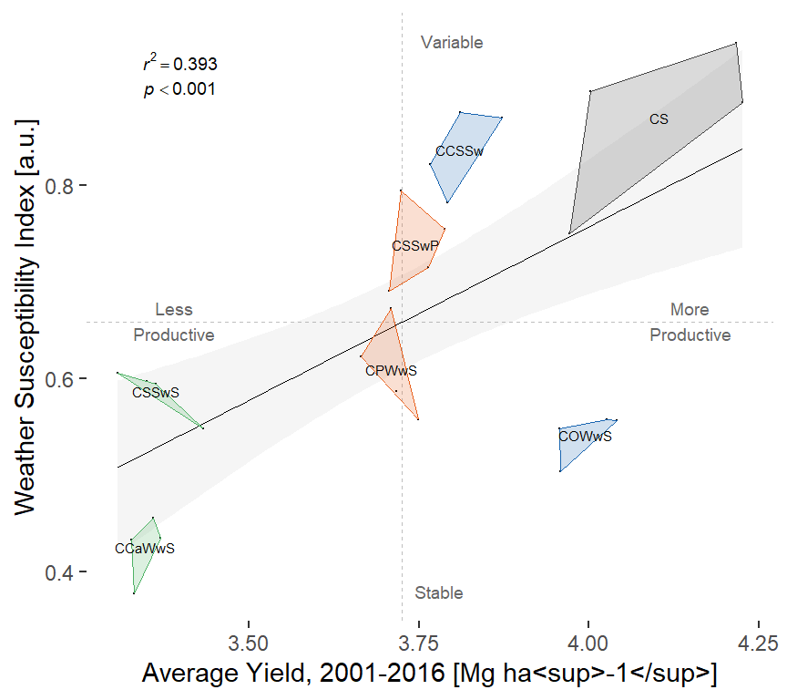

```r
ps_plt
```

# Risk and Reward

In low, average, and high years, what is the yield of each rotation?

```r
cutoff = qnorm(.75)
cutoff=1

gen_labels = function(cutoff) {
  q = pnorm(cutoff)

  tails = 1-q
  mid = 1-(2*q)

  perc = 100*c(tails, mid, tails) %>%
    round(2) %>%
    abs

  paste(c('Worst', 'Middle', 'Best'),
        perc) %>%
    paste0('%')
}
labs = gen_labels(cutoff)

ei$YEAR_TYPE = labs[2]
ei[ei$EI < -cutoff, 'YEAR_TYPE'] = labs[1]
ei[ei$EI >= cutoff, 'YEAR_TYPE'] = labs[3]

ei$YEAR_TYPE %<>% factor(levels=labs[3:1])

years_by_type = tapply(ei$YEAR, ei$YEAR_TYPE, function(x) length(unique(x)))

mod = lmer(YIELD ~ YEAR_TYPE * ROTATION + (1|REP/CYCLE_YEAR) + (1|CYCLE/CYCLE_YEAR), data=ei)
```

```
## boundary (singular) fit: see help('isSingular')
```

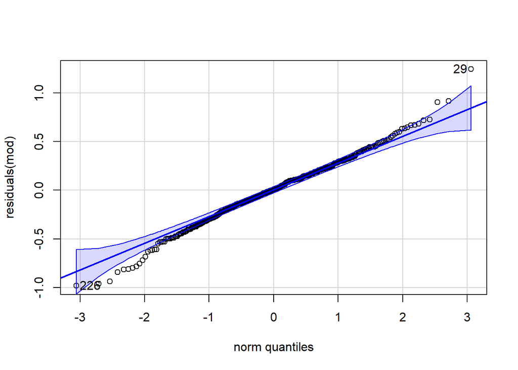

```
## [1]  29 226
```

```r
qqPlot(residuals(mod))
```

```r
Anova(mod, test.statistic='F')
```

|  | F | Df | Df.res | Pr(>F) |
| --- | --- | --- | --- | --- |
| YEAR_TYPE | 18.610878 | 2 | 24.83511 | 1.151445e-05 |
| ROTATION | 50.943054 | 6 | 401.20367 | 1.760297e-46 |
| YEAR_TYPE:ROTATION | 8.411261 | 12 | 401.20367 | 2.981276e-14 |

```r
em = emmeans(mod, ~ ROTATION | YEAR_TYPE)

cld(em, Letters=letters, reversed=TRUE, adjust='fdr')
```

|  | ROTATION | YEAR_TYPE | emmean | SE | df | lower.CL | upper.CL | .group |
| --- | --- | --- | --- | --- | --- | --- | --- | --- |
| 2 | CS | Best 16% | 5.439083 | 0.2330562 | 14.732720 | 4.711826 | 6.166341 | a |
| 3 | CCSSw | Best 16% | 5.175729 | 0.2330562 | 14.732720 | 4.448472 | 5.902987 | a |
| 6 | COWwS | Best 16% | 4.732542 | 0.2330562 | 14.732720 | 4.005284 | 5.459799 | b |
| 7 | CSSwP | Best 16% | 4.705610 | 0.2330562 | 14.732720 | 3.978352 | 5.432867 | b |
| 4 | CPWwS | Best 16% | 4.643940 | 0.2330562 | 14.732720 | 3.916683 | 5.371198 | b |
| 5 | CSSwS | Best 16% | 4.173721 | 0.2330562 | 14.732720 | 3.446464 | 4.900979 | c |
| 1 | CCaWwS | Best 16% | 3.950479 | 0.2330562 | 14.732720 | 3.223222 | 4.677737 | c |
| 9 | COWwS | Middle 68% | 3.947211 | 0.1074668 | 6.126019 | 3.521600 | 4.372821 | a |
| 10 | CS | Middle 68% | 3.929364 | 0.1074668 | 6.126019 | 3.503754 | 4.354975 | a |
| 13 | CSSwP | Middle 68% | 3.720288 | 0.1074668 | 6.126019 | 3.294678 | 4.145899 | b |

[output cut: 11 more lines]

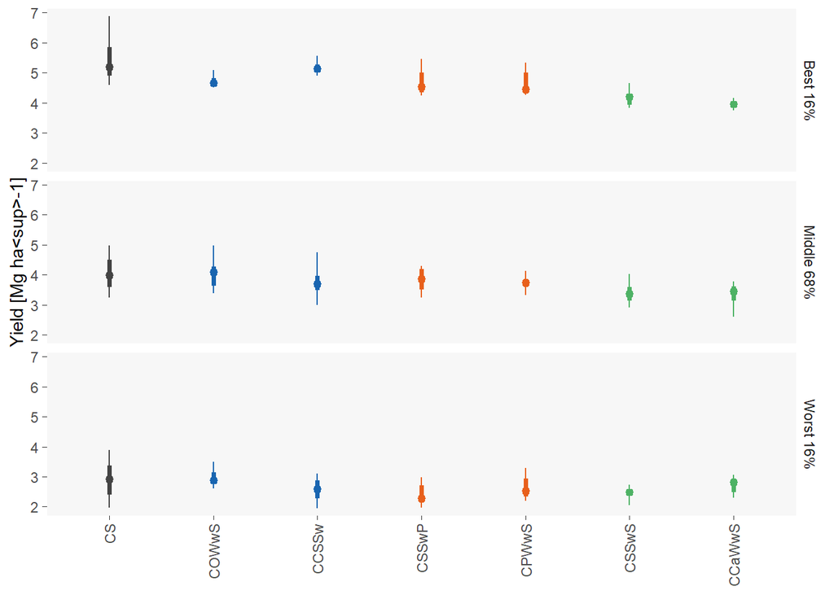

```r
tt = tapply(ei$YIELD, ei$ROTATION, mean) %>%
  sort(decreasing=TRUE)

ei$ROTATION_ORDER = factor(ei$ROTATION, levels=names(tt))

errorbar_quantiles = function(x, range) {
  y = range/2
  med = quantile(x, 0.5)
  low = quantile(x, y)
  hi = quantile(x, 1-y)
  return(data.frame(
    y = med,
    ymin = low,
    ymax = hi
  ))
}


risk_plt =
  ggplot(ei,
         aes(x=ROTATION_ORDER,
             y=YIELD,
             color=ROTATION)) +
  facet_wrap(~YEAR_TYPE,
             ncol=1,
             strip.position='right') +
  scale_color_manual(values=rot_colors) +
  stat_summary(fun.data=errorbar_quantiles,
             geom='pointrange',
             fun.args=list(range=0.05),
             size=0.1) +
  stat_summary(fun.data=errorbar_quantiles,
               geom='pointrange',
               fun.args=list(range=0.5),
               linewidth=1.4,
               size=0.3) +
  # stat_summary(fun.data=errorbar_range,
  #              geom='pointrange') +
  labs(x=NULL,
       y='Yield [Mg ha<sup>-1]') +
  guides(color='none') +
  theme(panel.grid=element_blank(),
        panel.background=element_rect(fill='#f7f7f7'),
        axis.text.x=element_text(angle=90,
                                 vjust=0.5,
                                 hjust=1),
        axis.ticks=element_line(linewidth=0.1),
        strip.background=element_blank(),
        axis.title=element_markdown())
risk_plt
```

Emphasizing that COWwS yields are quite reliable in poor years, with low downside risk. CS yields, meanwhile, can be excellent.

# Export

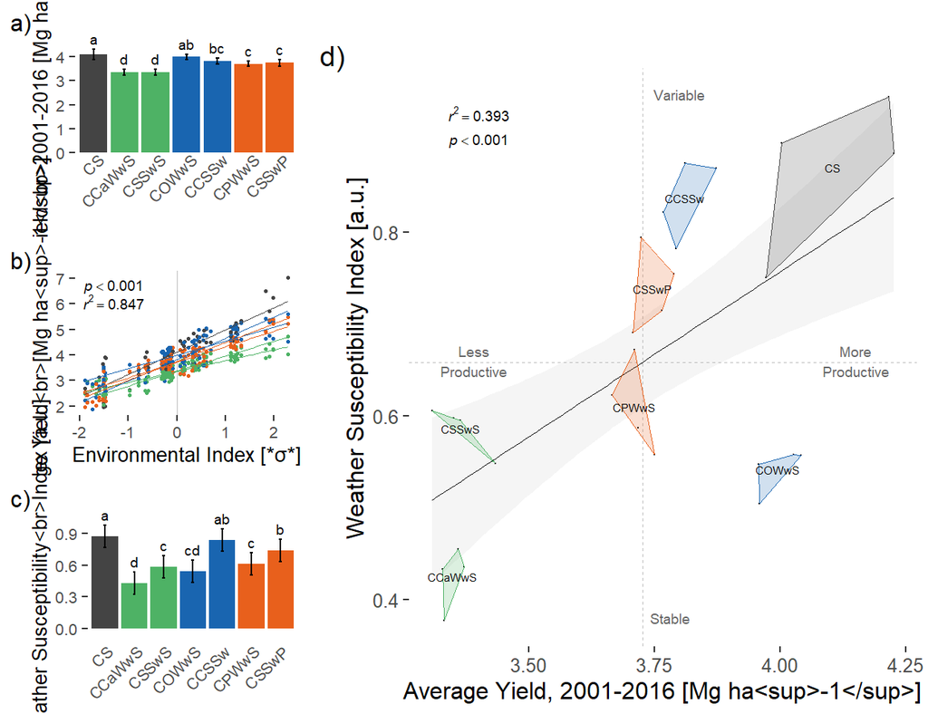

```r
p1 = productivity_plt +
  labs(tag='a)') +
  theme(axis.ticks.x=element_blank(),
        axis.text.x=element_text(angle=45, hjust=1, vjust=1.3),
        text=element_text(size=10))


p2 = ei_plt +
  guides(color='none') +
  labs(tag='b)') +
  theme(text=element_text(size=10))

p3 = stability_plt +
  labs(tag='c)') +
  theme(axis.text.x=element_text(angle=45, hjust=1, vjust=1),
        text=element_text(size=10))


p4 = ps_plt +
  guides(color='none') +
  labs(tag='\nd)') +
  theme(text=element_text(size=12))


# grid.arrange(p1, p2, p3, p4, nrow=2)

marrangeGrob(grobs=list(p1, p2, p3, p4),
             layout_matrix=rbind(c(1,1,4,4,4,4),
                                 c(2,2,4,4,4,4),
                                 c(3,3,4,4,4,4)),
             top=NULL)
```

```r
here('Results', 'Figure 2 - productivity and stability.jpg') %>%
  jpeg(width=6.5, height=5, units='in', res=300)
marrangeGrob(grobs=list(p1, p2, p3, p4),
             layout_matrix=rbind(c(1,1,4,4,4,4),
                                 c(2,2,4,4,4,4),
                                 c(3,3,4,4,4,4)),
             top=NULL)
```

```r
dev.off()
```

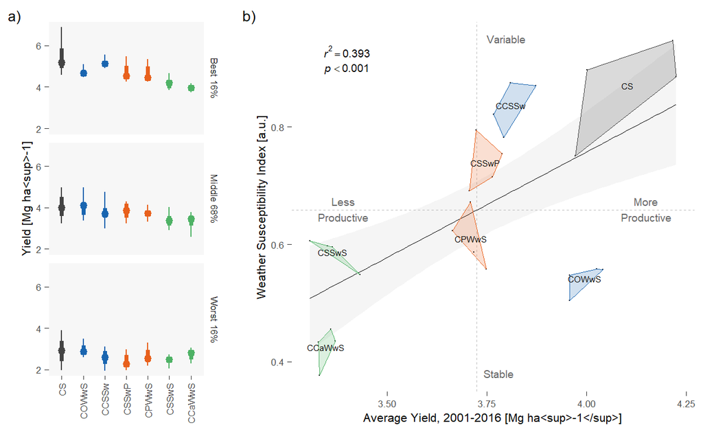

```r
p4 = ps_plt +
  guides(color='none') +
  labs(tag='b)') +
  theme(text=element_text(size=8),
        axis.ticks=element_line(linewidth=0.1))

p5 = risk_plt +
  scale_y_continuous(breaks=seq(2, 8, by=2)) +
  labs(tag='a)') +
  theme(text=element_text(size=8))

marrangeGrob(grobs=list(p5, p4),
             layout_matrix=rbind(c(1,1,2,2,2,2),
                                 c(1,1,2,2,2,2),
                                 c(1,1,2,2,2,2)),
             top=NULL)
```

```r
here('Results', 'Figure 2 ALT - productivity and stability.jpg') %>%
  jpeg(width=6.5, height=4, units='in', res=300)
marrangeGrob(grobs=list(p5, p4),
             layout_matrix=rbind(c(1,1,2,2,2,2),
                                 c(1,1,2,2,2,2),
                                 c(1,1,2,2,2,2)),
             top=NULL)
```

```r
dev.off()
```

```r
here('Results', 'Figure 2 - EI vs Yield.csv') %>%
  write.csv(prod_ei, ., row.names=FALSE)
```